# Capstone Project - Part 2

Saibal Bhattacharya

10/02/2020

# **1. Problem statement:**

The main question that this section of the capstone projects attempts to answer is:

Can highly ranked colleges/universities be identified using unsupervised machine learning algorithms? NOTE: Some of the criteria used for ranking are low admissions rate, high standardized test scores (75 percentile), high 4-year graduation rates.

# **2. Data:**

The dataset used for this capstone project is publicly available and was downloaded from https://public.tableau.com/en-us/s/resources.

The original data was compiled by the Integrated Postsecondary Education Data System (IPEDS). IPEDS serves as the primary source for data on colleges, universities, and technical and vocational postsecondary institutions in the United States, and it is part of the National Center for Education Statistics (NCES).

This dataset pertains to about 1534 US universities and colleges for the year 2013. It includes a host of information regarding institute name, location (state and geographic region), status (public or private not-for-profit), religiously affiliated (or not), historically black college (or not) and type of degrees offered. It also includes many undergraduate admission statistics (number of applications, admissions, yield), 25th and 75th percentile ACT and SAT scores, percent of freshmen submitting ACT and SAT scores, tuition and fees (from 2010 to 2014), in-state and out-of-state total price of attendance (2013-14),full- and part-time enrollment, ethnic/racial make-up, percent of in-state, out-of-state, international students, college endowment per FTE (full-time equvalent) enrollment, and percent of freshmen receiving various kinds of financial aid - local, federal, and institutional. Additionally, it also includes the graduation rate (for Bachelor’s degree) over 4, 5, and 6 years.

Additionally, this dataset includes some date that are not related to undergraduates such as ethnic/racial makeup of graduate school and total enrollment numbers across the college/university. It also includes some estimated statistics about enrollment for freshmen, undergraduates, graduates, and full- and part-time students.

## **2b. Focus on undergraduate data**

All colleges/universities have undergraduate programs, but graduate programs vary in size and scope across colleges and universities. For this project, I, therefore, decided to focus on answering questions pertaining to the undergraduate program only.

Thus from the original dataset, I removed all data that didn’t focus on undergraduates such as ethnic makeup of graduate programs, ethnic makeup of total enrollment (that included non-undergraduates). I also eliminated estimated enrollment numbers (total, undergraduate, and graduate), since the data base separately included (non-estimated) undergraduate enrollment data. I also excluded the number of degrees and certificates awarded (including Associate, Bachelor, Master’s, Doctoral, post baccalaureate, post Master’s, and various kinds of certificates) mainly because of large number of zero or missing values for these columns.

## **2c. Reference**

Reference for the K-means cluster analysis code and workflow: http://uc-r.github.io/kmeans_clustering#elbow

# **3. Procedural steps for K-means cluster analysis:**

1. Load data
2. Initial data processing
3. Check for duplication of college/university name
4. Create dummy variables for categorical variables
5. Scale data
6. Initial analysis - K-means clustering with two clusters
7. Define optimal number of clusters
   1. Elbow method
   2. Average Silhoutte method
   3. Gap statistic method
8. Final analysis - extracting results
   1. Elbow method ii.Gap analysis
9. Summary statistics - compare highly selective colleges with others

#### **Load library files:**

```r
library(tidyverse)  # data manipulation
library(cluster)    # clustering algorithms
library(factoextra) # clustering algorithms & visualization
```

```r
library(gridExtra)  # plot multiple charts for different k values
library(doBy)       # required for summaryBy - calculate summary statistics
library(caret)      #for on-hot encoding to generate dummy variables
```

#### **3a. Read in project data file**

```r
df1 <- read.csv("US_Univ_UG_shortnames.csv")
```

#### **3b. Initial data processing**

```r
#Check number of NAs in each column
sapply(df1, function(x) sum(is.na(x)))
```

```
##                 ID_number                      Name                        Yr
##                         0                         0                         0
##                       ZIP                    County                 Longitude
##                         0                         0                         0
##                  Latitude              Relgious_y_n                Applicants
##                         0                         0                       156
##                 Admission            UG1st_Enrolled              P_submit_SAT
##                       156                       156                       276
##              P_submit_ACT                SATRead_25                SATRead_75
##                       274                       364                       364
##                SATMath_25                SATMath_75               SATWrite_25
##                       351                       351                       819
##               SATWrite_75                ACTComp_25                ACTComp_75
##                       819                       334                       334
##                   P_admit                     Yield            Tuition2010_11
##                       157                       157                        43
##            Tuition2011_12            Tuition2012_13            Tuition2013_14
##                        43                        41                        37
##     Price_instate_2013_14    Price_outstate_2013_14                     State
##                       134                       134                         0
##                    Region                    Status                      HBCU
##                         0                         0                         0
##              Urbanization              Type_of_univ                 UG_enroll
##                         0                         0                         2
##               Grad_enroll               FTUG_enroll               PTUG_enroll
##                         2                         2                         2
##             P_Amer_Indian                   P_Asian             P_Af_American
##                        12                        12                        12
##                  P_Latino               P_PIslander                   P_White
##                        12                        12                        12
##              P_2orM_races                  P_RaceNA                 P_NRAlien
##                        12                        12                        12
##  P_Asian_Native_PIslander                   P_Women           P_1stUG_instate
##                        12                        12                       622
##          P_1stUG_outstate           P_1stUG_foreign             P_1stUG_resNA
##                       622                       622                       622
##             Gradrate_4yrs             Gradrate_5yrs             Gradrate_6yrs
##                        58                        58                        58
##           P_1yrUG_any_aid   P_1yrUG_Fed_state_grant         P_1yrUG_Fed_grant
##                        42                        42                        42
##        P_1yrUG_Pell_grant    P_1yrUG_otherFed_grant P_1yrUG_state_local_grant
##                        42                        42                        42
##   P_1yrUG_institute_grant      P_1yrUG_student_loan  P_1yrUG_Fed_student_loan
##                        42                        42                        42
##        P_1yrUG_other_loan      SB_Endowment_per_FTE
##                        42                        57
```

```r
nrow(df1)
```

```
## [1] 1533
```

```r
#Cull columns by name
#Remove select columns - that have identifier info
df2 <- df1[ , -which(names(df1) %in% c("ID_number","Yr", "ZIP", "County", "Longitude",
                                       "Latitude"))]

#Remove select columns - with large number of NA values
#Clustering algorithm requirement - NA values can't be present in any column
df3 <- df2[ , -which(names(df2) %in% c("P_1stUG_instate", "P_1stUG_outstate", "P_1stUG_foreign", "P_1stUG_resNA", "SATWrite_25", "SATWrite_75"))]

#Remove rows with NA values in any column
df4 <- df3[complete.cases(df3), ]
nrow(df4)  #Rows without NA values = 1066
```

```
## [1] 1066
```

```r
#Check if any column has NA values
sapply(df4, function(x) sum(is.na(x))) #None of the columns have any NA values
```

```
##                      Name              Relgious_y_n                Applicants
##                         0                         0                         0
##                 Admission            UG1st_Enrolled              P_submit_SAT
##                         0                         0                         0
##              P_submit_ACT                SATRead_25                SATRead_75
##                         0                         0                         0
##                SATMath_25                SATMath_75                ACTComp_25
##                         0                         0                         0
##                ACTComp_75                   P_admit                     Yield
##                         0                         0                         0
##            Tuition2010_11            Tuition2011_12            Tuition2012_13
##                         0                         0                         0
##            Tuition2013_14     Price_instate_2013_14    Price_outstate_2013_14
##                         0                         0                         0
##                     State                    Region                    Status
##                         0                         0                         0
##                      HBCU              Urbanization              Type_of_univ
##                         0                         0                         0
##                 UG_enroll               Grad_enroll               FTUG_enroll
##                         0                         0                         0
##               PTUG_enroll             P_Amer_Indian                   P_Asian
##                         0                         0                         0
##             P_Af_American                  P_Latino               P_PIslander
##                         0                         0                         0
##                   P_White              P_2orM_races                  P_RaceNA
##                         0                         0                         0
##                 P_NRAlien  P_Asian_Native_PIslander                   P_Women
##                         0                         0                         0
##             Gradrate_4yrs             Gradrate_5yrs             Gradrate_6yrs
##                         0                         0                         0
##           P_1yrUG_any_aid   P_1yrUG_Fed_state_grant         P_1yrUG_Fed_grant
##                         0                         0                         0
##        P_1yrUG_Pell_grant    P_1yrUG_otherFed_grant P_1yrUG_state_local_grant
##                         0                         0                         0
##   P_1yrUG_institute_grant      P_1yrUG_student_loan  P_1yrUG_Fed_student_loan
##                         0                         0                         0
##        P_1yrUG_other_loan      SB_Endowment_per_FTE
##                         0                         0
```

#### **3c. Check if university/college name is duplicated under Name column**

##### University/college name will be used as row name, so can’t have two rows with same name

```r
#Find all universities that have the same name
df5 <- df4
dupe = df5[,c('Name')] # select columns to check duplicates
df6 <- df5[duplicated(dupe) | duplicated(dupe, fromLast=TRUE),]
#fromLast = TRUE option used as it returns TRUE only from the duplicate value on-wards

#Extract all info about universities that have the same names
df6b <- select(df6, Name, Relgious_y_n, State, Region, Status, HBCU, Urbanization,
               Type_of_univ)

#Arrange universities in alphabetical order
df6c <- df6b[order(df6b[,'Name']), ]

#Display universities/colleges with same name
df6d <- select(df6c, Name, State, Region)
head(df6d, 13)
```

```
##                         Name          State          Region
## 339      Anderson University        Indiana     Great_Lakes
## 1182     Anderson University South Carolina      South_East
## 409          Bethany College         Kansas          Plains
## 1417         Bethany College  West Virginia      South_East
## 625        Bethel University      Minnesota          Plains
## 1225       Bethel University      Tennessee      South_East
## 457            Union College       Kentucky      South_East
## 895            Union College       New York        Mid_East
## 649  University of St Thomas      Minnesota          Plains
## 1294 University of St Thomas          Texas      South_West
## 701      Westminster College       Missouri          Plains
## 1167     Westminster College   Pennsylvania        Mid_East
## 1338     Westminster College           Utah Rocky_Mountains
```

#### **Observation: Some universities may have same names but are located in different states**

##### So universities are NOT duplicates - though their Names are same

```r
#So create new column that combines Name and State - to make each entry unique
df5$Name_State <- paste(df5$Name, '_', df5$State)

#Check if all entries in Name_State column are unique - i.e., there are no duplicates
length(unique(df5$Name_State)) == nrow(df5)
```

```
## [1] TRUE
```

```r
#Returns TRUE if there are no duplicates

#Name rows using contents of Name_State column
df7 <- df5[,-57]
rownames(df7) <- df5[,57]

#Remove columns: Name and State
#Categorical variable State is removed - as Region carries this information
df8 <- df7[ , -which(names(df7) %in% c("Name", "State"))]
```

#### **3d. Create dummy variables - for categorical variables**

##### Use one-hot function to create dummy variables

```r
# For categorical variables - use one-hot to create dummy variables
one_hot <- dummyVars(~ ., df8, fullRank = FALSE)
df8_hot <- predict(one_hot, df8) %>% as.data.frame()

#Change/shorten column names - make them easier to read
df8b_hot <- df8_hot
names(df8b_hot)[names(df8b_hot) == "Relgious_y_nNo"] <- "Religious_n"
names(df8b_hot)[names(df8b_hot) == "Relgious_y_nYes"] <- "Religious_y"
names(df8b_hot)[names(df8b_hot) == "RegionFar_West"] <- "Region_FarWest"
names(df8b_hot)[names(df8b_hot) == "RegionGreat_Lakes"] <- "Region_GreatLakes"
names(df8b_hot)[names(df8b_hot) == "RegionMid_East"] <- "Region_MidEast"
names(df8b_hot)[names(df8b_hot) == "RegionNew_England"] <- "Region_NewEngland"
names(df8b_hot)[names(df8b_hot) == "RegionPlains"] <- "Region_Plains"
names(df8b_hot)[names(df8b_hot) == "RegionRocky_Mountains"] <- "Region_Rockies"
names(df8b_hot)[names(df8b_hot) == "RegionSouth_East"] <- "Region_SouthEast"
names(df8b_hot)[names(df8b_hot) == "RegionSouth_West"] <- "Region_SouthWest"
names(df8b_hot)[names(df8b_hot) == "StatusPrivate not-for-profit"] <- "Private"
names(df8b_hot)[names(df8b_hot) == "StatusPublic"] <- "Public"
names(df8b_hot)[names(df8b_hot) == "UrbanizationCity: Large"] <- "Urban_City_L"
names(df8b_hot)[names(df8b_hot) == "UrbanizationCity: Midsize"] <- "Urban_City_M"
names(df8b_hot)[names(df8b_hot) == "UrbanizationCity: Small"] <- "Urban_City_S"
names(df8b_hot)[names(df8b_hot) == "UrbanizationRural: Distant"] <- "Urban_Rural_D"
names(df8b_hot)[names(df8b_hot) == "UrbanizationRural: Fringe"] <- "Urban_Rural_F"
names(df8b_hot)[names(df8b_hot) == "UrbanizationRural: Remote"] <- "Urban_Rural_R"
names(df8b_hot)[names(df8b_hot) == "UrbanizationSuburb: Large"] <- "Urban_Suburb_L"
names(df8b_hot)[names(df8b_hot) == "UrbanizationSuburb: Midsize"] <- "Urban_Suburb_M"
names(df8b_hot)[names(df8b_hot) == "UrbanizationSuburb: Small"] <- "Urban_Suburb_S"
names(df8b_hot)[names(df8b_hot) == "UrbanizationTown: Distant"] <- "Urban_Town_D"
names(df8b_hot)[names(df8b_hot) == "UrbanizationTown: Fringe"] <- "Urban_Town_F"
names(df8b_hot)[names(df8b_hot) == "UrbanizationTown: Remote"] <- "Urban_Town_R"
names(df8b_hot)[names(df8b_hot) == "Type_of_univBS_&_Associate's"] <- "Univ_BS_Assoc"
names(df8b_hot)[names(df8b_hot) == "Type_of_univBS_Arts_&_Sciences"] <- "Univ_BS_Arts_Sci"
names(df8b_hot)[names(df8b_hot) == "Type_of_univBS_Diverse_fields"] <- "Univ_BS_Diverse"
names(df8b_hot)[names(df8b_hot) == "Type_of_univDoctoral_Research"] <- "Univ_Doc_Res"
names(df8b_hot)[names(df8b_hot) == "Type_of_univHigh_research_univ"] <- "Univ_High_Res"
names(df8b_hot)[names(df8b_hot) == "Type_of_univMS_Large_program"] <- "Univ_MS_L"
names(df8b_hot)[names(df8b_hot) == "Type_of_univMS_Medium_program"] <- "Univ_MS_M"
names(df8b_hot)[names(df8b_hot) == "Type_of_univMS_Small_program"] <- "Univ_MS_S"
names(df8b_hot)[names(df8b_hot) == "Type_of_univVery_High_research_univ"] <- "Univ_vHigh_Res"
colnames(df8b_hot)
```

```
##  [1] "Religious_n"               "Religious_y"
##  [3] "Applicants"                "Admission"
##  [5] "UG1st_Enrolled"            "P_submit_SAT"
##  [7] "P_submit_ACT"              "SATRead_25"
##  [9] "SATRead_75"                "SATMath_25"
## [11] "SATMath_75"                "ACTComp_25"
## [13] "ACTComp_75"                "P_admit"
## [15] "Yield"                     "Tuition2010_11"
## [17] "Tuition2011_12"            "Tuition2012_13"
## [19] "Tuition2013_14"            "Price_instate_2013_14"
## [21] "Price_outstate_2013_14"    "Region_FarWest"
## [23] "Region_GreatLakes"         "Region_MidEast"
## [25] "Region_NewEngland"         "Region_Plains"
## [27] "Region_Rockies"            "Region_SouthEast"
## [29] "Region_SouthWest"          "Private"
```

[output cut: 27 more lines]

#### **3e. Data scaling**

```r
#Data must be standardized (i.e., scaled) to make variables comparable.
#standardization: transforming variables so they have mean zero and standard deviation 1.
#scaling/standardizing the data using the R function called "scale"
#don’t want the clustering algorithm to depend to an arbitrary variable unit
df9 <- scale(df8b_hot)
```

#### **3f. K-means clustering - Initial run with 2 clusters**

##### 1st step - indicate the number of clusters (k) that will be generated in the final solution

```r
#Default - R software uses 10 as the default value for the maximum iterations for convergence
#compute k-means in R with the "kmeans" function
#will group the data into two clusters (centers = 2)
#"nstart" option - attempts multiple initial configurations and reports on the best one
# nstart = 25 - will generate 25 initial configurations
k2 <- kmeans(df9, centers = 2, nstart = 25)
str(k2)
```

```
## List of 9
##  $ cluster     : Named int [1:1066] 1 1 1 2 2 1 1 1 1 1 ...
##   ..- attr(*, "names")= chr [1:1066] "University of Alabama at Birmingham _ Alabama" "University of Alabama in Huntsville _ Alabama" "Alabama State University _ Alabama" "The University of Alabama _ Alabama" ...
##  $ centers     : num [1:2, 1:83] -0.142 0.488 0.142 -0.488 -0.336 ...
##   ..- attr(*, "dimnames")=List of 2
##   .. ..$ : chr [1:2] "1" "2"
##   .. ..$ : chr [1:83] "Religious_n" "Religious_y" "Applicants" "Admission" ...
##  $ totss       : num 88395
##  $ withinss    : num [1:2] 57124 19789
##  $ tot.withinss: num 76913
##  $ betweenss   : num 11482
##  $ size        : int [1:2] 826 240
##  $ iter        : int 1
##  $ ifault      : int 0
##  - attr(*, "class")= chr "kmeans"
```

#### **Observation**

##### Output details:

###### **cluster:** A vector of integers (from 1:k) indicating the cluster to which each point is allocated.

###### **centers:** A matrix of cluster centers.

###### **totss:** The total sum of squares.

###### **withinss:** Vector of within-cluster sum of squares, one component per cluster.

###### **tot.withinss:** Total within-cluster sum of squares, i.e. sum(withinss).

###### **betweenss:** The between-cluster sum of squares, i.e. $totss-tot.withinss$.

###### **size:** The number of points in each cluster.

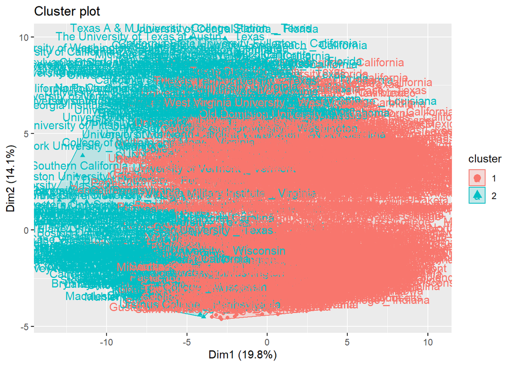

```r
#View results by using fviz_cluster
fviz_cluster(k2, data = df9)
```

#### **Results:**

##### Using two clusters results in grouping the universities/colleges into two groups, and it doesn’t help to distinguish top universities from the rest.

##### Thus, need to use established techniques to determine the optimal number of clusters.

#### **NOTE:**

##### If there are more than two dimensions (variables) fviz_cluster will perform principal component analysis (PCA) and plot the data points according to the first two principal components that explain the majority of the variance.

#### **3g. Define optimal number of clusters**

##### 3 most popular methods to find optimal clusters: Elbow & Silhouette methods, Gap statistics

#### **3g(i). Define optimal number of clusters - Elbow method**

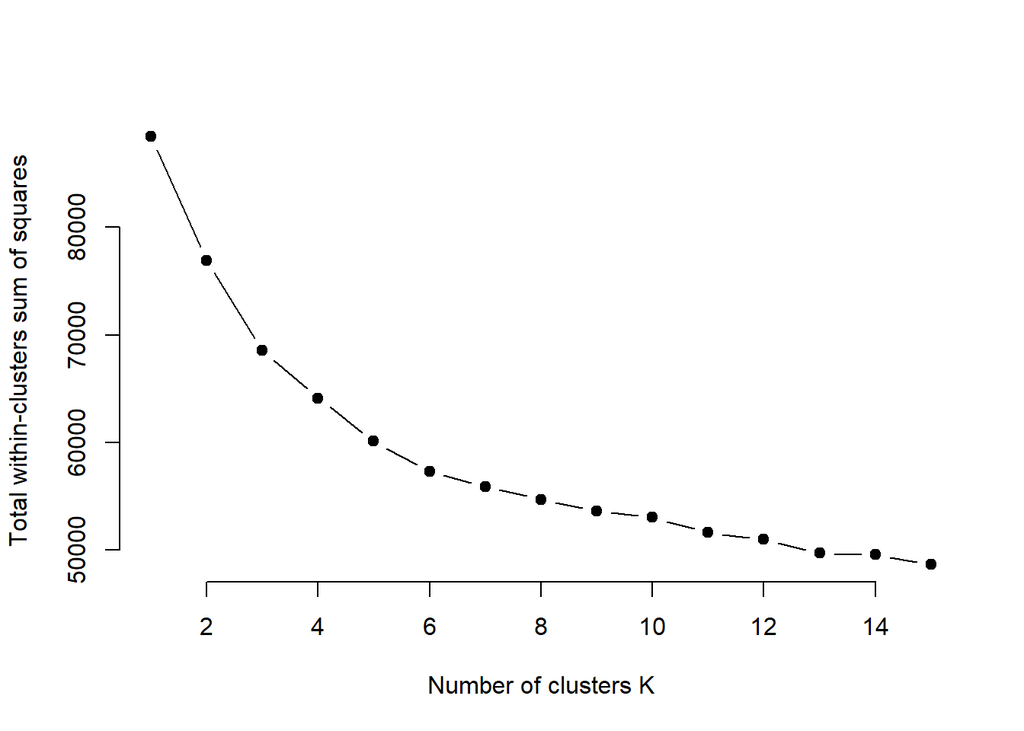

```r
# Total intra-cluster variation (total within-cluster variation or total within-cluster sum of square) is minimized
# The location of a bend (knee) in the plot is generally considered as an indicator of the appropriate number of clusters.

set.seed(123)

# function to compute total within-cluster sum of square
wss <- function(k) {
  kmeans(df9, k, nstart = 10 )$tot.withinss
}

# Compute and plot wss for k = 1 to k = 15
k.values <- 1:15

# extract wss for 2-15 clusters
wss_values <- map_dbl(k.values, wss)

plot(k.values, wss_values,
     type="b", pch = 19, frame = FALSE,
     xlab="Number of clusters K",
     ylab="Total within-clusters sum of squares")
```

#### **Results:**

##### 6 clusters appear to be optimum - as the (bend of) the knee occurs near it.

#### **3g(ii). Define optimal number of clusters - Average Silhouette Method**

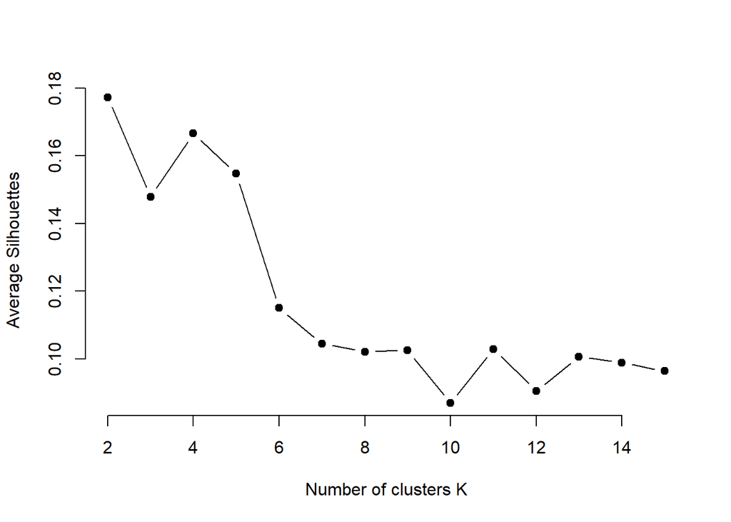

```r
#Average Silhouette Method - measures the quality of a clustering, i.e.,
#how well each object lies within its cluster
#A high average silhouette width indicates a good clustering
#optimal number of clusters k is the one that maximizes the average silhouette
#over a range of possible values for k
#Use the silhouette function in the cluster package to compuate the average silhouette width.
avg_sil <- function(k) {
  km.res <- kmeans(df9, centers = k, nstart = 25)
  ss <- silhouette(km.res$cluster, dist(df9))
  mean(ss[, 3])
}

# Compute and plot wss for k = 2 to k = 15
k.values <- 2:15

# extract avg silhouette for 2-15 clusters
avg_sil_values <- map_dbl(k.values, avg_sil)

plot(k.values, avg_sil_values,
     type = "b", pch = 19, frame = FALSE,
     xlab = "Number of clusters K",
     ylab = "Average Silhouettes")
```

#### **Results:**

##### 2 clusters appear to be optimum, with 4 clusters coming in as second optimal number of clusters.

#### **3g(iii). Define optimal number of clusters - Gap Statistic Method**

```r
#The gap statistic compares the total intracluster variation for different values of k
#with their expected values under null reference distribution of the data
#(i.e. a distribution with no obvious clustering).
#The reference dataset is generated using Monte Carlo simulations of the sampling process.
#The estimate of the optimal clusters (Gapn(k)) will be the value that maximizes Gapn(k)
#This means that the clustering structure is far away from the uniform distribution of points.

#To compute the gap statistic method we can use the clusGap function
#which provides the gap statistic and standard error for an output.
# Compute gap statistic
set.seed(123)
gap_stat <- clusGap(df9, FUN = kmeans, nstart = 25,
                    K.max = 10, B = 50)
```

[output not shown]

```r
# Print the result
print(gap_stat, method = "firstmax")
```

```
## Clustering Gap statistic ["clusGap"] from call:
## clusGap(x = df9, FUNcluster = kmeans, K.max = 10, B = 50, nstart = 25)
## B=50 simulated reference sets, k = 1..10; spaceH0="scaledPCA"
##  --> Number of clusters (method 'firstmax'): 10
##           logW   E.logW       gap      SE.sim
##  [1,] 8.109993 8.921010 0.8110168 0.002614152
##  [2,] 8.042688 8.875840 0.8331522 0.002493029
##  [3,] 7.981075 8.858583 0.8775078 0.002471629
##  [4,] 7.947587 8.845375 0.8977882 0.002327627
##  [5,] 7.918455 8.836921 0.9184668 0.002199647
##  [6,] 7.893286 8.829516 0.9362292 0.002122651
##  [7,] 7.879051 8.823011 0.9439594 0.002084939
##  [8,] 7.867036 8.817160 0.9501246 0.002245982
##  [9,] 7.856726 8.811908 0.9551817 0.002115404
## [10,] 7.847983 8.806971 0.9589876 0.002167466
```

#### **Results:**

##### The highest value for gap = 0.959 for cluster = 10, while 5 clusters result in gap = 0.919.

#### **NOTE:**

##### K.max can be increased to avoid convergence errors but run time slows down significantly.

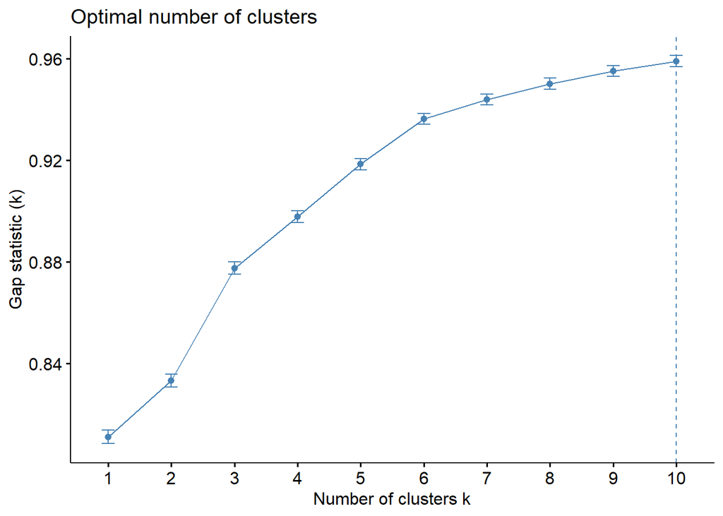

```r
#visualize the results
fviz_gap_stat(gap_stat)
```

#### **Results:**

##### The highest value for gap = 0.959 for cluster = 10

#### **3h. Final analysis - extracting results**

#### **3h(i). Final analysis - extracting results using Elbow analysis**

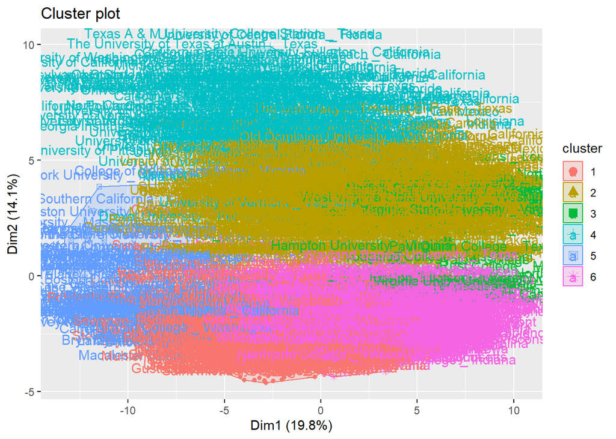

```r
# The Elbow method suggests that 6 is the number of optimal clusters
# perform the final analysis and extract the results using 6 clusters.
# Compute k-means clustering with k = 6
set.seed(123)
final_Elbow <- kmeans(df9, 6, nstart = 25)

#visualize the results using fviz_cluster
fviz_cluster(final_Elbow, data = df9)
```

```r
#Find cluster of best university/colleges
df9b <- as.data.frame(final_Elbow$cluster)
head(df9b)
```

```
##                                               final_Elbow$cluster
## University of Alabama at Birmingham _ Alabama                   2
## University of Alabama in Huntsville _ Alabama                   2
## Alabama State University _ Alabama                              3
## The University of Alabama _ Alabama                             4
## Auburn University _ Alabama                                     4
## Birmingham Southern College _ Alabama                           1
```

#### **Results:**

##### Top colleges/universities are all in cluster 5. Cluster 5 has 80 members.

#### **3h(ii). Final analysis - extracting results using Gap analysis**

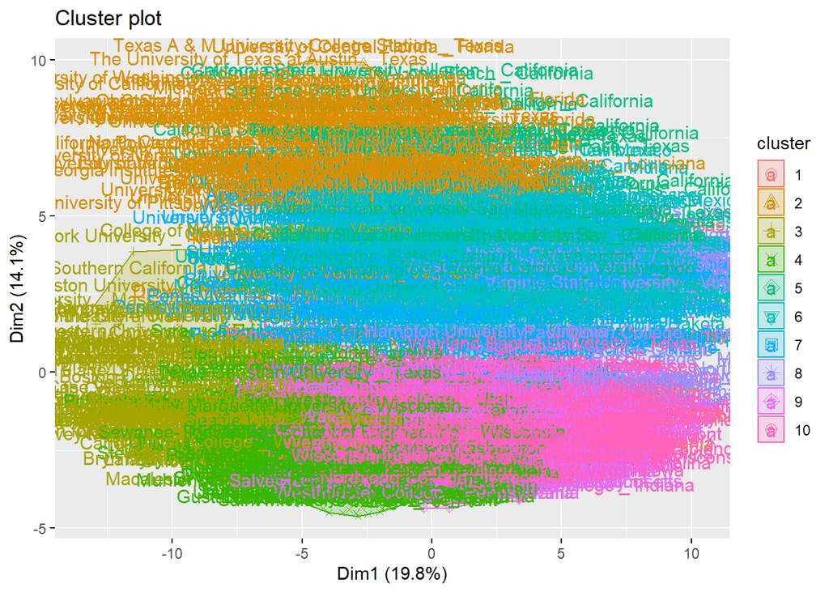

```r
# Extract results based on Gap analysis results
# The Gap analysis indicates that 10 is the number of optimal clusters
# Perform the final analysis and extract the results using 10 clusters.
# Compute k-means clustering with k = 10
set.seed(123)
final_Gap <- kmeans(df9, 10, nstart = 25)

#visualize the results using fviz_cluster
fviz_cluster(final_Gap, data = df9)
```

```r
#Find cluster of best university/colleges
df9c <- as.data.frame(final_Gap$cluster)
head(df9c)
```

```
##                                               final_Gap$cluster
## University of Alabama at Birmingham _ Alabama                 6
## University of Alabama in Huntsville _ Alabama                 6
## Alabama State University _ Alabama                            8
## The University of Alabama _ Alabama                           2
## Auburn University _ Alabama                                   2
## Birmingham Southern College _ Alabama                         4
```

#### **Results:**

##### Top colleges are all in cluster 3. Cluster 3 has 80 members.

##### So it seems that top colleges/universities are identified with equal effectiveness when using k = 6 (from Elbow analysis) or k = 10 (from Gap analysis).

#### **3i. Summary statistics - compare clusters**

##### Metrics chosen to compare clusters: ACTComp_75, SATRead_75, SATMath_75, P_admit, Gradrate_4yrs.

##### Both Gap and Elbow analysis show that the cluster containing Ivy league colleges have 80 members.

##### So 6 clusters (from Elbow analysis) are selected to comparison analysis.

##### Higher number of clusters (like 10 from Gap Analysis) may cause some of the clusters to overlap.

```r
#Compare 6 clusters from Elbow analysis
#Extract cluster number and row name - from Elbow analysis
df10 <- as.data.frame(final_Elbow$cluster)

#Merge cluster number with original unscaled data
#df8 - contains unscaled data (all numerical columns only)
df11 <- merge(df10, df8, by="row.names", all=TRUE)

#Rename column names
df12 <- df11 %>% rename(Univ_Name = "Row.names", Cluster_no = "final_Elbow$cluster") #load library(dplyr)

#To compare using box and violin plots - convert Cluster_no into factor
df12$Cluster_no <- as.factor(df12$Cluster_no)

#Compare ACTComp_75 across clusters
summaryBy(ACTComp_75 ~ Cluster_no, data = df12,      #install library(doBy)
          FUN = list(mean, max, min, median, sd))
```

```
##   Cluster_no ACTComp_75.mean ACTComp_75.max ACTComp_75.min ACTComp_75.median
## 1          1        27.71245             32             22              28.0
## 2          2        24.39841             31             19              24.0
## 3          3        19.77083             26             14              19.5
## 4          4        27.85000             33             20              28.0
## 5          5        32.63750             35             29              33.0
## 6          6        24.19774             30             17              24.0
##   ACTComp_75.sd
## 1      1.886584
## 2      1.957712
## 3      2.271372
## 4      2.512092
## 5      1.469037
## 6      2.049085
```

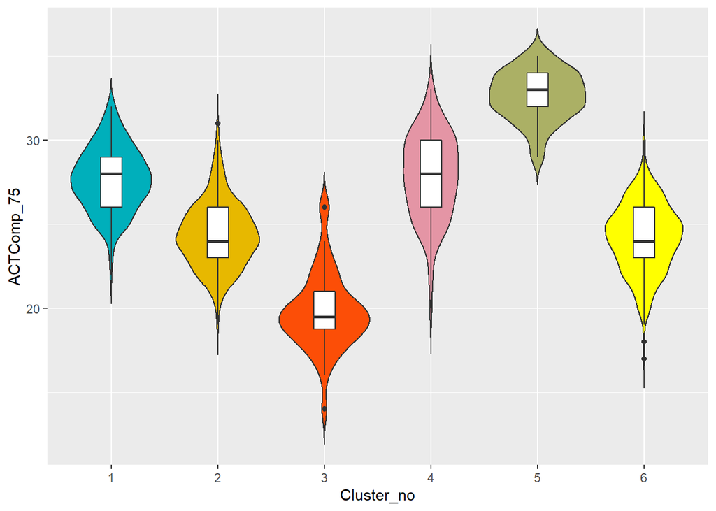

```r
e <- ggplot(df12, aes(x = Cluster_no, y = ACTComp_75))

#Compare using box plots embedded within violin plots
e + geom_violin(aes(fill = Cluster_no), trim = FALSE) +
  geom_boxplot(width = 0.2)+
  scale_fill_manual(values = c("#00AFBB", "#E7B800", "#FC4E07", "#E495A5", "#ABB065",
                               "#FFFF00FF"))+
  theme(legend.position = "none")
```

#### **Observations:**

##### Cluster 5 (includes Ivy plus colleges/universities) - has highest ACT Composite 75 percentile scores

```r
#Compare SATRead_75 across clusters
summaryBy(SATRead_75 ~ Cluster_no, data = df12,
          FUN = list(mean, max, min, median, sd))
```

```
##   Cluster_no SATRead_75.mean SATRead_75.max SATRead_75.min SATRead_75.median
## 1          1        617.3605            720            510             620.0
## 2          2        557.5378            720            460             550.0
## 3          3        478.2083            650            360             470.0
## 4          4        617.6500            720            480             620.0
## 5          5        730.4750            800            630             736.5
## 6          6        548.1328            670            420             550.0
##   SATRead_75.sd
## 1      40.38808
## 2      43.44516
## 3      50.66660
## 4      45.10065
## 5      37.70571
## 6      44.98255
```

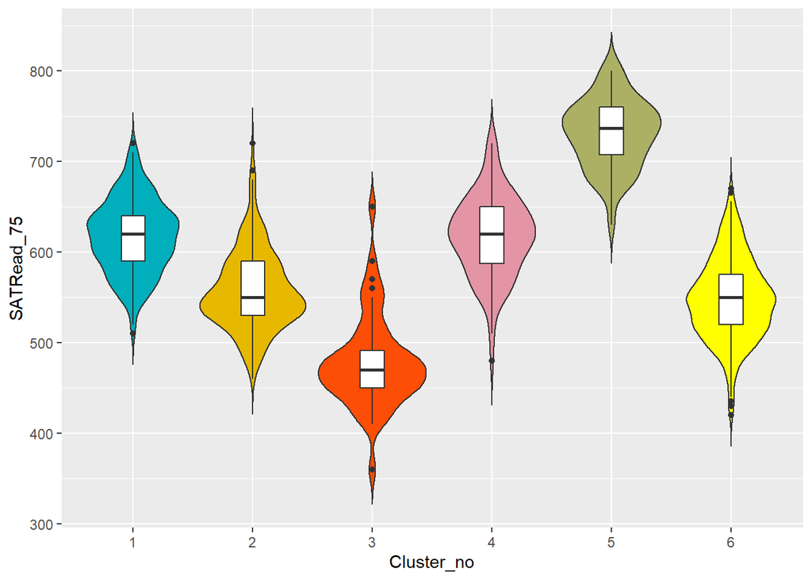

```r
e <- ggplot(df12, aes(x = Cluster_no, y = SATRead_75))

#Compare using box plots embedded within violin plots
e + geom_violin(aes(fill = Cluster_no), trim = FALSE) +
  geom_boxplot(width = 0.2)+
  scale_fill_manual(values = c("#00AFBB", "#E7B800", "#FC4E07", "#E495A5", "#ABB065",
                               "#FFFF00FF"))+
  theme(legend.position = "none")
```

#### **Observations:**

##### Cluster 5 (includes Ivy plus colleges/universities) - has highest SAT Reading 75 percentile scores

```r
#Compare SATMath_75 across clusters
summaryBy(SATMath_75 ~ Cluster_no, data = df12,
          FUN = list(mean, max, min, median, sd))
```

```
##   Cluster_no SATMath_75.mean SATMath_75.max SATMath_75.min SATMath_75.median
## 1          1        623.8112            740            530               620
## 2          2        569.1554            700            460               560
## 3          3        480.8750            640            410               470
## 4          4        646.3800            780            510               640
## 5          5        745.2000            800            670               750
## 6          6        551.7797            680            440               550
##   SATMath_75.sd
## 1      37.12965
## 2      41.22014
## 3      44.38594
## 4      55.02007
## 5      36.60511
## 6      41.04060
```

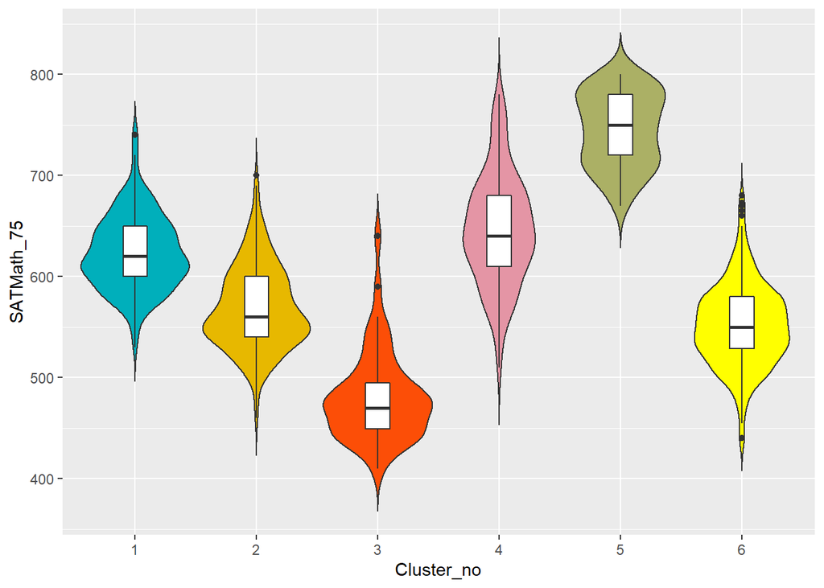

```r
e <- ggplot(df12, aes(x = Cluster_no, y = SATMath_75))

#Compare using box plots embedded within violin plots
e + geom_violin(aes(fill = Cluster_no), trim = FALSE) +
  geom_boxplot(width = 0.2)+
  scale_fill_manual(values = c("#00AFBB", "#E7B800", "#FC4E07", "#E495A5", "#ABB065",
                               "#FFFF00FF"))+
  theme(legend.position = "none")
```

#### **Observations:**

##### Cluster 5 (includes Ivy plus colleges/universities) - has highest SAT Math 75 percentile scores

```r
#Compare P_admit across clusters
summaryBy(P_admit ~ Cluster_no, data = df12,
          FUN = list(mean, max, min, median, sd))
```

```
##   Cluster_no P_admit.mean P_admit.max P_admit.min P_admit.median P_admit.sd
## 1          1     68.25751          96          37           69.0   11.91394
## 2          2     71.25100         100          33           72.0   14.71451
## 3          3     50.58333          99          14           49.5   17.69461
## 4          4     60.61000          97          18           62.0   16.48010
## 5          5     26.01250          57           6           26.0   12.86787
## 6          6     66.40395         100          13           66.0   15.20448
```

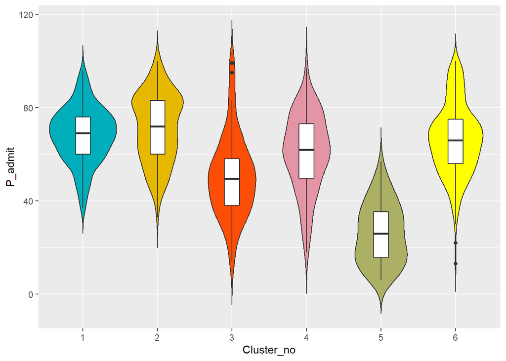

```r
e <- ggplot(df12, aes(x = Cluster_no, y = P_admit))

#Compare using box plots embedded within violin plots
e + geom_violin(aes(fill = Cluster_no), trim = FALSE) +
  geom_boxplot(width = 0.2)+
  scale_fill_manual(values = c("#00AFBB", "#E7B800", "#FC4E07", "#E495A5", "#ABB065",
                               "#FFFF00FF"))+
  theme(legend.position = "none")
```

#### **Observations:**

##### Cluster 5 (includes Ivy plus colleges/universities) - has the lowest admission rates

```r
#Compare Gradrate_4yrs across clusters
summaryBy(Gradrate_4yrs ~ Cluster_no, data = df12,
          FUN = list(mean, max, min, median, sd))
```

```
##   Cluster_no Gradrate_4yrs.mean Gradrate_4yrs.max Gradrate_4yrs.min
## 1          1           57.18884                83                11
## 2          2           25.74502                66                 4
## 3          3           17.41667                60                 1
## 4          4           41.05000                86                 7
## 5          5           81.72500                93                 0
## 6          6           34.44068                62                 0
##   Gradrate_4yrs.median Gradrate_4yrs.sd
## 1                 58.0         12.85860
## 2                 23.0         12.60185
## 3                 15.5         12.36129
## 4                 39.5         18.76348
## 5                 84.0         11.39728
## 6                 34.5         12.12065
```

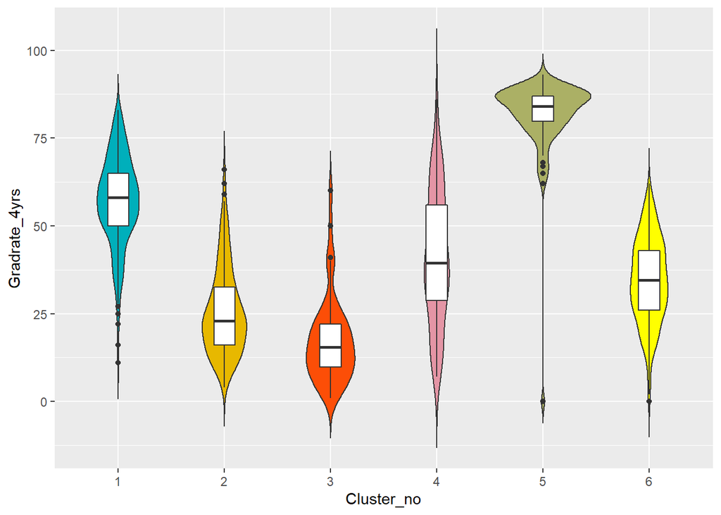

```r
e <- ggplot(df12, aes(x = Cluster_no, y = Gradrate_4yrs))

#Compare using box plots embedded within violin plots
e + geom_violin(aes(fill = Cluster_no), trim = FALSE) +
  geom_boxplot(width = 0.2)+
  scale_fill_manual(values = c("#00AFBB", "#E7B800", "#FC4E07", "#E495A5", "#ABB065",
                               "#FFFF00FF"))+
  theme(legend.position = "none")
```

#### **Observations:**

##### Cluster 5 (includes Ivy plus colleges/universities) - has the highest 4-yr graduation rates

# **Results:**

##### Cluster 5 stands out against all other cluster in terms of highest mean values for ACTComp_75, SATRead_75, SATMath_75, and Gradrate_4yrs. As expected, it has the lowest admissions rate P_admit.

##### Thus, the K-means clustering algorithm is an effective tool to identify the best performning colleges/universities.